# Farmer_age

Wenlong

4/29/2018

## 美国农民的平均年龄竟然是58岁！

随着我国城市化的发展，农村的壮劳力逐渐减少，越来越多的年轻人宁可家乡的土地撂荒，也要去外地的工厂打工。在美国也出现了类似的情况。据美国农业统计局在2012年的最新统计，美国农民主要从业者(principal operator)的平均年龄是**58.3**岁；并且农民“老龄化”的趋势已经延续了近30年。

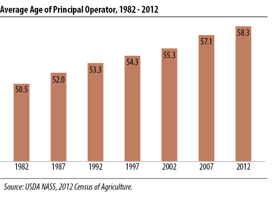

自1982年起，**美国农民的平均年龄就超过了50岁**；30多年来，平均年龄缓慢但顽强的增长到了58.3岁。在可预见的未来，**美国农民的年龄还会继续增加**。

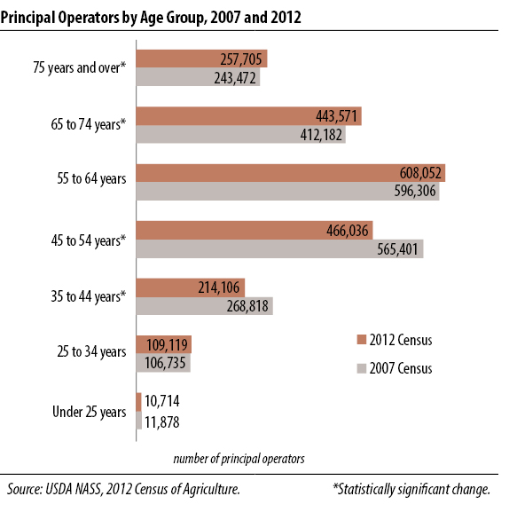

## 美国农民老龄化的原因浅析

造成美国农民老龄化的原因很多，笔者认为大致有以下几点：

- 1. 美国的农业机械化程度高，**老年人仍有很强的生产力**;
- 2. 农场的价格日益增加，很多年轻人没有财力购买农场；
- 3. 美国年轻人也认为**农民比较“土”，不体面**，更愿意在城市生活。

## 农民老龄化的潜在影响

很多美国农民比较保守，不太接受新事物，很多人竟然还在使用老款的2G手机。说实话，笔者第一次在地里看到一个农民拿出翻盖手机的时候，心里是有点蒙圈的。

然而现在很多新技术日新月异，农业领域也在进行各种各样的技术革新，包括**无人机的广泛应用**、**机器学习和人工智能的逐步推广**、**大数据精准农业的快速发展**，都要求农业从业者要有接受新思维的能力和意愿。

这个农民老龄化带来的**“代沟”**逐渐成为了新技术推广的障碍之一，农业领域的政策制定者已经意识到了这个问题，计划从多个角度来缓解乃至解决这一问题。

## Take-home points

- 美国农业老龄化严重，主要从业者平均年龄为58.3岁；
- 老龄化问题暂时没有缓解的趋势；
- 农民老龄化带来的“代沟”逐渐成为了新技术推广的障碍之一。

The end. Thanks for reading.

[figure not shown]